# Анализ данных о продаже автомобилей на рынке Приднестровья

Содержание:

- Выбор параметров
- Импорт библиотек и функций и данных
  - Загрузка библиотек
  - Загрузка функций
  - Загрузка данных
- Предобработка данных
  - Преобразование колонок
  - Предобработка дубликатов
  - Преобразование признака дата парсинга
  - Преобразование признака дата загрузки обявления
  - преобразование признака класс автомобиля
  - преобразование признака title
  - преобразование признака объем автомобиля
  - преобразование признака тип_двигателя
  - Преобразование признака цена
  - Преобразование признака доп инфо
  - Преобразование признака год
  - Преобразование признака body
  - Преобразование признака state
  - Преобразование признака door
  - Преобразование признака fuel
  - Преобразование признака transmission
  - Преобразование признака conditioner
  - Преобразование признака audio
  - Преобразование признака mileage
  - Преобразование признака contact
  - Преобразование признака fone
- Работа с пропусками
- Разбиение данных
- Анализ
  - Анализ выбросов в числовых данных.
  - Таргет
  - Категориальные признаки
  - Анализ данных во времени.
    - Анализ числовых признаков
    - Анализ Категориальных признаков
  - Корреляционный анализ
  - Промежуточные выводы
- Обучение моделей
  - Деление на выборки
  - Построение пайплана
  - Построение модели
    - Случайный лес
    - Градиентный бустинг
    - Градиентный бустинг
    - Дерево решений
    - Логистическая регрессия
    - Ядерный метод опорных векторов
  - Промежуточные выводы
  - Тестирование
    - Проверка лучшей модели на тестовых данных
    - Оценим влияние признаков
  - Итоговые выводы

Данные будут загружатся со следующего источника http://klaksona.net/

## Выбор параметров

выбор рандом стаит и тест сплит

Выбор доли пропусков в столбцах подлежащих удалению

курс евро к доллару

курс пмр к доллару

уровень мультиколлениарности выбранный для baseline

# Импорт библиотек и функций и данных

## Загрузка библиотек

## Загрузка функций

## Загрузка данных

[output not shown]

[output cut: 48 more lines]

[output not shown]

# Предобработка данных

|  | id | title | url | date_parsing | brend | volume | тип_двигателя | год | prise | dop_info | class_auto | body | state | door | fuel | transmission | conditioner | audio | mileage | contact | fone | date_notice |
| --- | --- | --- | --- | --- | --- | --- | --- | --- | --- | --- | --- | --- | --- | --- | --- | --- | --- | --- | --- | --- | --- | --- |
| 0 | auto1727728 | Toyota Avensis | http://klaksona.net/avtorynok-pmr/auto1727728.html | 2025-01-28 | Toyota | 2000 | Турбодизель | 2009 | 5900$ | • Toyota Avensis 2009 г.в. T27• Двигатель 2.0 D4D 126 лошадок.• Свежепригнана из Италии .• Машина в отличном состоянии.• Расход топлива: Город - 7 л/100 км, Трасса 5л/100 км.• Ходовая сбитая , ничего … | Легковой | универсал | Отличное | 4/5 | дизель | 6-тиступ.мех. | климатконтроль | автомагнитолаCD/MP3(сUSBиBluetooth) | 212000.00 | Toyota(Всеобъявленияэтогопользователя) | 077910407 | сегодняв21:32 |
| 1 | auto1727727 | Volkswagen Caddy | http://klaksona.net/avtorynok-pmr/auto1727727.html | 2025-01-28 | Volkswagen | 2000 | Бензин-Газ | 2007 | 6200$ | NaN | Легковой | минивен | Отличное | 4/5 | бензин | 5-тиступ.мех. | климатконтроль | автомагнитолаCD/MP3(безUSB) | 190.00 | Caddy | 77742794 | сегодняв21:23 |

```
(11475, 22)
```

## Преобразование колонок

```
Index(['id', 'title', 'url', 'date_parsing', 'brend', 'volume',
       'tip_dvigatelja', 'god', 'prise', 'dop_info', 'class_auto', 'body',
       'state', 'door', 'fuel', 'transmission', 'conditioner', 'audio',
       'mileage', 'contact', 'fone', 'date_notice'],
      dtype='object')
```

## Предобработка дублекатов

```
id
auto1677052    2
auto799009     1
auto1727715    1
auto1727716    1
auto1727717    1
              ..
auto1727710    1
auto1727711    1
auto1727712    1
auto1727713    1
auto1727714    1
Name: title, Length: 11474, dtype: int64
```

|  | id | title | url | date_parsing | brend | volume | tip_dvigatelja | god | prise | dop_info | class_auto | body | state | door | fuel | transmission | conditioner | audio | mileage | contact | fone | date_notice |
| --- | --- | --- | --- | --- | --- | --- | --- | --- | --- | --- | --- | --- | --- | --- | --- | --- | --- | --- | --- | --- | --- | --- |
| 5331 | auto1677052 | Спецтехника Автобус | http://klaksona.net/avtorynok-pmr/auto1677052.html | 2025-01-28 | Спецтехника | неуказано | неуказано | 1915 | договорная\n\n\n\n\n\n\n | NaN | NaN | NaN | NaN | NaN | NaN | NaN | NaN | NaN | NaN | иииии(Всеобъявленияэтогопользователя) | 111111 | 13.08.202412:09 |

|  | id | title | url | date_parsing | brend | volume | tip_dvigatelja | god | prise | dop_info | class_auto | body | state | door | fuel | transmission | conditioner | audio | mileage | contact | fone | date_notice |
| --- | --- | --- | --- | --- | --- | --- | --- | --- | --- | --- | --- | --- | --- | --- | --- | --- | --- | --- | --- | --- | --- | --- |
| 5330 | auto1677052 | Спецтехника Автобус | http://klaksona.net/avtorynok-pmr/auto1677052.html | 2025-01-28 | Спецтехника | неуказано | неуказано | 1915 | договорная\n\n\n\n\n\n\n | NaN | NaN | NaN | NaN | NaN | NaN | NaN | NaN | NaN | NaN | иииии(Всеобъявленияэтогопользователя) | 111111 | 13.08.202412:09 |
| 5331 | auto1677052 | Спецтехника Автобус | http://klaksona.net/avtorynok-pmr/auto1677052.html | 2025-01-28 | Спецтехника | неуказано | неуказано | 1915 | договорная\n\n\n\n\n\n\n | NaN | NaN | NaN | NaN | NaN | NaN | NaN | NaN | NaN | NaN | иииии(Всеобъявленияэтогопользователя) | 111111 | 13.08.202412:09 |

Удалили дубликаты из данных.

## Преобразование признака дата парсинга

|  | date_parsing |
| --- | --- |
| isna | 0 |
| isna_pst | 0.00 |
| count | 11474 |
| nunique | 1 |
| dtypes | object |
| sample | 2025-01-28 |

Приобразовали признак в тип datetime64

## Преобразование признака дата загрузки обявления

|  | date_notice |
| --- | --- |
| isna | 0 |
| isna_pst | 0.00 |
| count | 11474 |
| nunique | 11117 |
| dtypes | object |
| sample | 19.12.202312:49 |

|  | id | title | url | date_parsing | brend | volume | tip_dvigatelja | god | prise | dop_info | class_auto | body | state | door | fuel | transmission | conditioner | audio | mileage | contact | fone | date_notice |
| --- | --- | --- | --- | --- | --- | --- | --- | --- | --- | --- | --- | --- | --- | --- | --- | --- | --- | --- | --- | --- | --- | --- |

Удаляем данные с пропусками в признаке дата загрузки

приобразовали признак в тип datetime64 и вычислили из данного признака новый признак с месяцем и годом загрузки обявления

## преобразование признака класс автомобиля

|  | class_auto |
| --- | --- |
| isna | 2903 |
| isna_pst | 25.30 |
| count | 8571 |
| nunique | 7 |
| dtypes | object |
| sample | Легковой |

```
array(['Легковой', nan, 'Грузовой', 'спецтехника', 'Мототехника',
       'Водныйтраспорт', 'Автобус', 'Велотехника'], dtype=object)
```

Оставили только легковые и грузовые автомобили а также данные у которых нет информащии об этом признаке

## преобразование признака title

|  | title |
| --- | --- |
| isna | 0 |
| isna_pst | 0.00 |
| count | 10906 |
| nunique | 709 |
| dtypes | object |
| sample | Mercedes-Benz A-klasse A 180 |

Оставили в данных только данные с автомобилями, которые продаются а также добавили признак модель автомобиля вырезанныйй из названия автомобиля

## преобразование признака объем автомобиля

|  | volume |
| --- | --- |
| isna | 0 |
| isna_pst | 0.00 |
| count | 9006 |
| nunique | 405 |
| dtypes | object |
| sample | 2600 |

Удалили информацию об объеме для объявлений с ошибочным объемом.

## преобразование признака тип_двигателя

|  | tip_dvigatelja |
| --- | --- |
| isna | 0 |
| isna_pst | 0.00 |
| count | 9006 |
| nunique | 9 |
| dtypes | object |
| sample | Бензин |

```
array(['Турбодизель', 'Бензин-Газ', 'Гибрид', 'Бензин', 'CDI',
       'неуказано', 'Электро', 'Дизель', 'Компрессор'], dtype=object)
```

## Преобразование признака цена

|  | prise |
| --- | --- |
| isna | 0 |
| isna_pst | 0.00 |
| count | 9006 |
| nunique | 821 |
| dtypes | object |
| sample | договорная\n\n\n\n\n\n\n |

преобразовали данные посредством функции и удалили данные о машинах дешевле 1000 Добавили прихнак с категорией цены автомобиля

## Преобразование признака доп инфо

|  | dop_info |
| --- | --- |
| isna | 987 |
| isna_pst | 12.40 |
| count | 6977 |
| nunique | 6679 |
| dtypes | object |
| sample | Находится в Тирасполе.В отличном состоянии.Обслуживался вовремя.Европеец.- 2010 год- 3.5 Гибрид- Автомат- 199.000 км- Полный привод!!! Возможно оформить в АВТОКРЕДИТ на 5 лет!!!В месяц выходит - $228П… |

Добавили признак длина строки о дополнительной информации

## Преобразование признака год

|  | god |
| --- | --- |
| isna | 0 |
| isna_pst | 0.00 |
| count | 7964 |
| nunique | 83 |
| dtypes | int64 |
| sample | 2010 |

```
array([2009, 2007, 1997, 2012, 2008, 2013, 2015, 2011, 2018, 2006, 1999,
       2019, 2016, 2010, 2014, 1995, 2003, 1998, 1990, 2024, 1987, 2022,
       2021, 2002, 2001, 1991, 1996, 1993, 2017, 2004, 2005, 2000, 1994,
       1992, 1989, 2020, 2023, 1988, 1980, 1986, 1985, 1984, 1901, 1916,
       1903, 1927, 1906, 1983, 1935, 1921, 1981, 1905, 1902, 1915, 1982,
       1912, 1956, 1913, 1900, 1918, 1966, 1965, 1974, 1937, 1917, 1914,
       1979, 1908, 1904, 1958, 1923, 1924, 1977, 1932, 1947, 1970, 1973,
       1972, 1975, 1968, 1967, 1978, 1960])
```

удалили неверные данные за последние 6 лет

## Преобразование признака body

|  | body |
| --- | --- |
| isna | 1201 |
| isna_pst | 15.60 |
| count | 6483 |
| nunique | 18 |
| dtypes | object |
| sample | внедорожник |

```
array(['универсал', 'минивен', 'хетчбек', nan, 'внедорожник', 'седан',
       'кроссовер', 'купе', 'кабриолет', 'фургон', 'грузовой',
       'микроавтобус', 'автобус', 'спецтехника', 'лимузин', 'велотехника',
       'комплектующие/деталь', 'пикап', 'мототехника'], dtype=object)
```

удалили из данных объявления относящиеся к мототехнике, спецтехнике прицепам и запчастям

## Преобразование признака state

|  | state |
| --- | --- |
| isna | 1057 |
| isna_pst | 13.80 |
| count | 6617 |
| nunique | 6 |
| dtypes | object |
| sample | Отличное |

```
array(['Отличное', 'Хорошее', 'Новый', nan, 'Удовлетворительное',
       'Битыйавто', 'Плохое'], dtype=object)
```

Даннный признак не изменяли.

## Преобразование признака door

|  | door |
| --- | --- |
| isna | 1340 |
| isna_pst | 17.50 |
| count | 6334 |
| nunique | 3 |
| dtypes | object |
| sample | 4/5 |

```
array(['4/5', nan, '2/3', '6/7'], dtype=object)
```

Даннный признак не изменяли.

## Преобразование признака fuel

|  | fuel |
| --- | --- |
| isna | 1088 |
| isna_pst | 14.20 |
| count | 6586 |
| nunique | 4 |
| dtypes | object |
| sample | дизель |

```
array(['дизель', 'бензин', nan, 'газ', 'электро'], dtype=object)
```

Даннный признак не изменяли.

## Преобразование признака transmission

|  | transmission |
| --- | --- |
| isna | 884 |
| isna_pst | 11.50 |
| count | 6790 |
| nunique | 6 |
| dtypes | object |
| sample | 5-тиступ.мех. |

```
array(['6-тиступ.мех.', '5-тиступ.мех.', 'автомат', nan, '4-ёхступ.мех.',
       'роботизированая', 'полуавтомат'], dtype=object)
```

Даннный признак не изменяли.

## Преобразование признака conditioner

|  | conditioner |
| --- | --- |
| isna | 1637 |
| isna_pst | 21.30 |
| count | 6037 |
| nunique | 3 |
| dtypes | object |
| sample | климатконтроль |

```
array(['климатконтроль', 'кондиционер', nan, 'безкондиционера'],
      dtype=object)
```

Даннный признак не изменяли.

## Преобразование признака audio

|  | audio |
| --- | --- |
| isna | 2352 |
| isna_pst | 30.60 |
| count | 5322 |
| nunique | 4 |
| dtypes | object |
| sample | автомагнитолаCD/MP3(сUSBиBluetooth) |

```
array(['автомагнитолаCD/MP3(сUSBиBluetooth)',
       'автомагнитолаCD/MP3(безUSB)', 'автомагнитолаHi-End', nan,
       'автомагнитола'], dtype=object)
```

Даннный признак не изменяли.

## Преобразование признака mileage

|  | mileage |
| --- | --- |
| isna | 1719 |
| isna_pst | 22.40 |
| count | 5955 |
| nunique | 1134 |
| dtypes | float64 |
| sample | 210.00 |

Добавили прихнак с оризинальной информацией о пробеге автомобиля удалив из него информацию об автомобилях с пробегом менее 5000 и более 600000 км. Исправили ошибки в признаке с информацией о прбеге

## Преобразование признака contact

|  | contact |
| --- | --- |
| isna | 5 |
| isna_pst | 0.10 |
| count | 7669 |
| nunique | 1409 |
| dtypes | object |
| sample | 077811616(Всеобъявленияэтогопользователя) |

Обработали информацию о имени пользователя

## Преобразование признака fone

|  | fone |
| --- | --- |
| isna | 0 |
| isna_pst | 0.00 |
| count | 7674 |
| nunique | 4806 |
| dtypes | object |
| sample | 077789309 |

```
7674
```

Обработали информацию о номерах телефонов продавцов

# Работа с пропусками

|  | index | 0 |
| --- | --- | --- |
| 26 | mileage_orig | 52.76 |
| 17 | audio | 30.65 |
| 18 | mileage | 25.68 |
| 16 | conditioner | 21.33 |
| 8 | prise | 21.02 |
| 24 | q_prise | 21.02 |
| 13 | door | 17.46 |
| 11 | body | 15.65 |
| 10 | class_auto | 14.97 |
| 14 | fuel | 14.18 |
| 12 | state | 13.77 |
| 9 | dop_info | 12.68 |
| 5 | volume | 12.12 |
| 15 | transmission | 11.52 |
| 6 | tip_dvigatelja | 8.67 |
| 1 | title | 0.00 |
| 0 | id | 0.00 |
| 4 | brend | 0.00 |
| 2 | url | 0.00 |
| 7 | god | 0.00 |
| 3 | date_parsing | 0.00 |
| 19 | contact | 0.00 |
| 20 | fone | 0.00 |
| 22 | month | 0.00 |
| 21 | date_notice | 0.00 |
| 23 | model | 0.00 |
| 25 | len_dop_info | 0.00 |

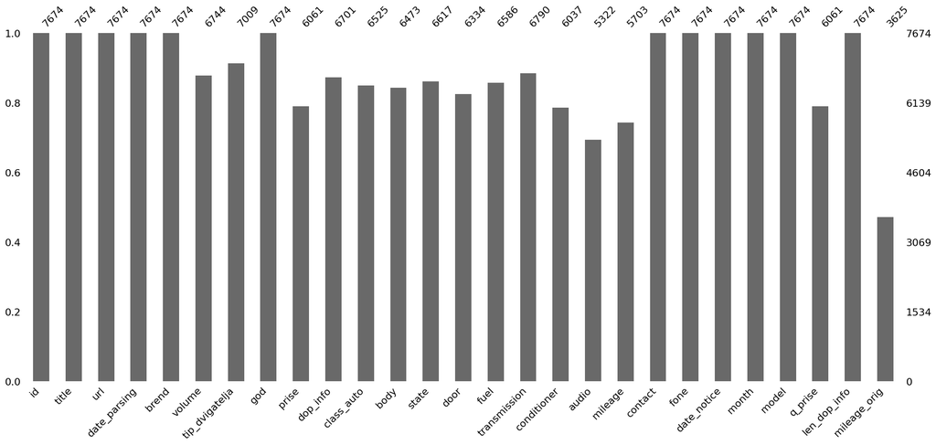

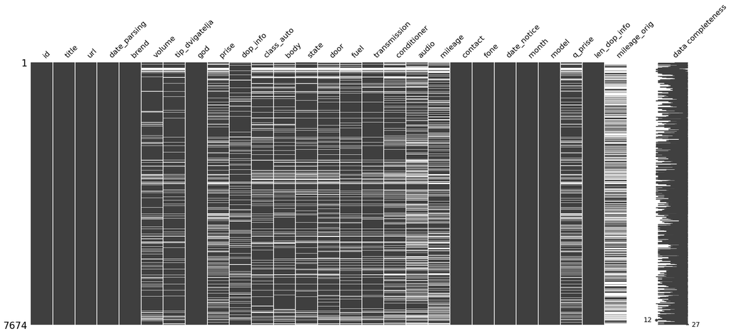

Создаем списки с фичами, таргетом, списки с удаляемыми фичами

```
Index(['id', 'title', 'url', 'date_parsing', 'brend', 'volume',
       'tip_dvigatelja', 'god', 'prise', 'dop_info', 'class_auto', 'body',
       'state', 'door', 'fuel', 'transmission', 'conditioner', 'audio',
       'mileage', 'contact', 'fone', 'date_notice', 'month', 'model',
       'q_prise', 'len_dop_info', 'mileage_orig'],
      dtype='object')
```

```
['title', 'url', 'dop_info', 'class_auto']
НЕ_ОК
```

|  | index | 0 |
| --- | --- | --- |
| 22 | mileage_orig | 48.16 |
| 13 | audio | 25.99 |
| 14 | mileage | 18.89 |
| 12 | conditioner | 16.60 |
| 9 | door | 12.41 |
| 7 | body | 11.14 |
| 8 | state | 8.79 |
| 10 | fuel | 8.56 |
| 11 | transmission | 6.24 |
| 3 | volume | 6.10 |
| 4 | tip_dvigatelja | 3.58 |
| 0 | id | 0.00 |
| 5 | god | 0.00 |
| 1 | date_parsing | 0.00 |
| 2 | brend | 0.00 |
| 6 | prise | 0.00 |
| 15 | contact | 0.00 |
| 17 | date_notice | 0.00 |
| 16 | fone | 0.00 |
| 18 | month | 0.00 |
| 19 | model | 0.00 |
| 20 | q_prise | 0.00 |
| 21 | len_dop_info | 0.00 |

```
<class 'pandas.core.frame.DataFrame'>
Index: 6061 entries, 0 to 9005
Data columns (total 23 columns):
 #   Column          Non-Null Count  Dtype
---  ------          --------------  -----
 0   id              6061 non-null   object
 1   date_parsing    6061 non-null   datetime64[ns]
 2   brend           6061 non-null   object
 3   volume          5691 non-null   float64
 4   tip_dvigatelja  5844 non-null   object
 5   god             6061 non-null   int64
 6   prise           6061 non-null   float64
 7   body            5386 non-null   object
 8   state           5528 non-null   object
 9   door            5309 non-null   object
 10  fuel            5542 non-null   object
 11  transmission    5683 non-null   object
 12  conditioner     5055 non-null   object
 13  audio           4486 non-null   object
 14  mileage         4916 non-null   float64
 15  contact         6061 non-null   object
 16  fone            6061 non-null   object
 17  date_notice     6061 non-null   datetime64[ns]
 18  month           6061 non-null   period[M]
 19  model           6061 non-null   object
 20  q_prise         6061 non-null   object
 21  len_dop_info    6061 non-null   int64
 22  mileage_orig    3142 non-null   float64
dtypes: datetime64[ns](2), float64(4), int64(2), object(14), period[M](1)
memory usage: 1.1+ MB
```

# Разбиение данных

```
id: 6061
date_parsing: 1
brend: 61
volume: 234
tip_dvigatelja: 5
god: 47
prise: 602
body: 14
state: 6
door: 3
fuel: 4
transmission: 6
conditioner: 3
audio: 4
mileage: 688
contact: 1190
fone: 3938
date_notice: 5940
month: 26
model: 562
q_prise: 6
len_dop_info: 974
mileage_orig: 676
```

```
delete_features=[
    'date_parsing',
]
categorical_nominal_features = [
    'id',
    'brend',
    'tip_dvigatelja',
    'body',
    'state',
    'door',
    'fuel',
    'transmission',
    'conditioner',
    'audio',
    'contact',
    'fone',
    'model',
    'q_prise',
]
categorical_ordinal_features = [

]
numerical_features = [
    'volume',
    'god',
    'prise',
    'mileage',
    'date_notice',
    'month',
    'len_dop_info',
    'mileage_orig',
]
not_information_features = [
]
```

```
['date_parsing']
OK
```

Разбили данные на цифровые и категориальные.

# Анализ

## Анализ выбросов в числовых данных.

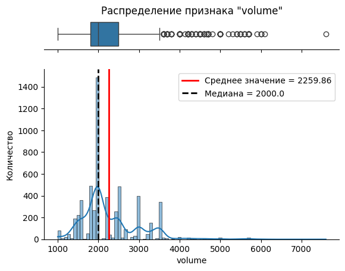

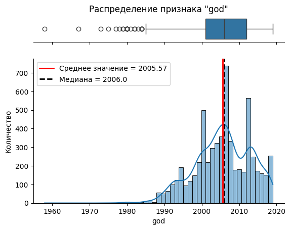

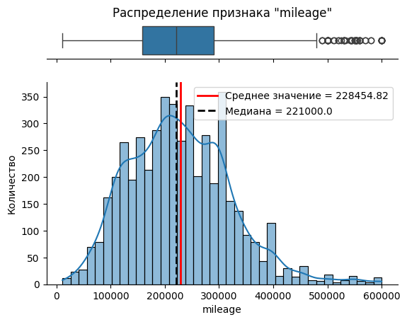

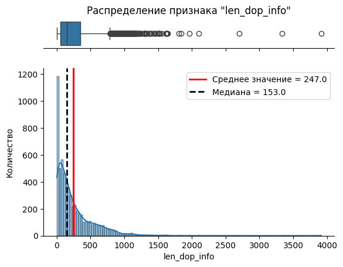

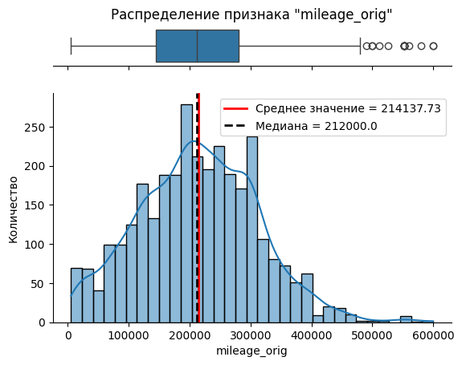

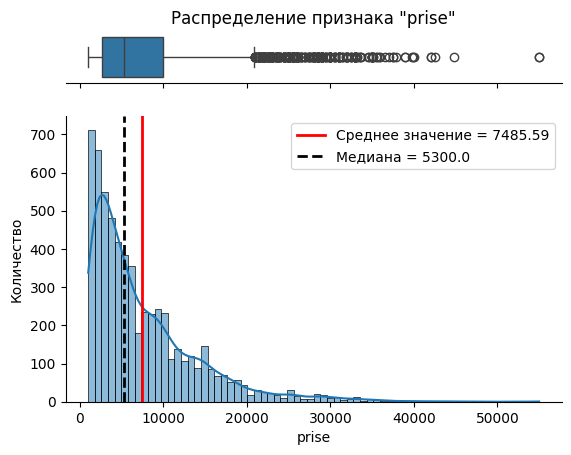

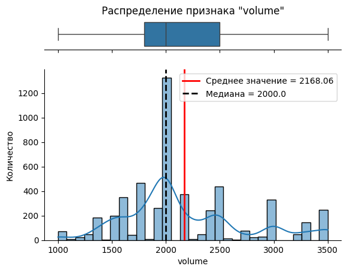

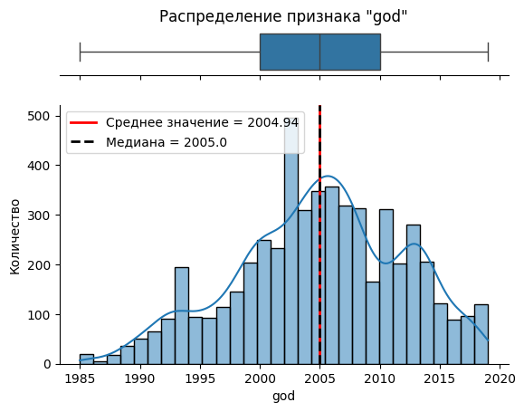

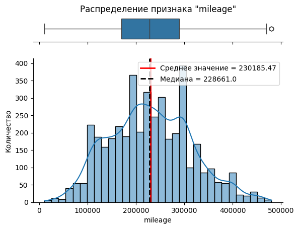

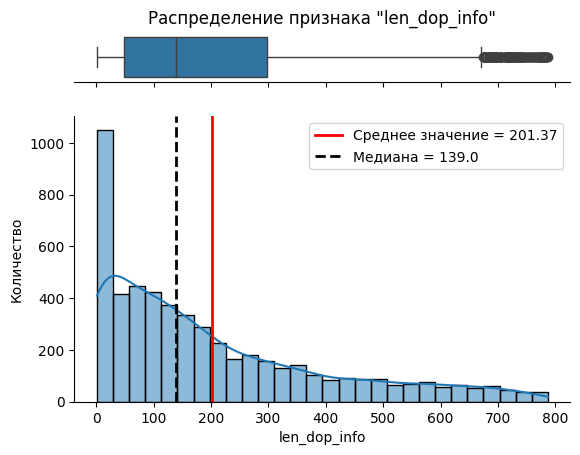

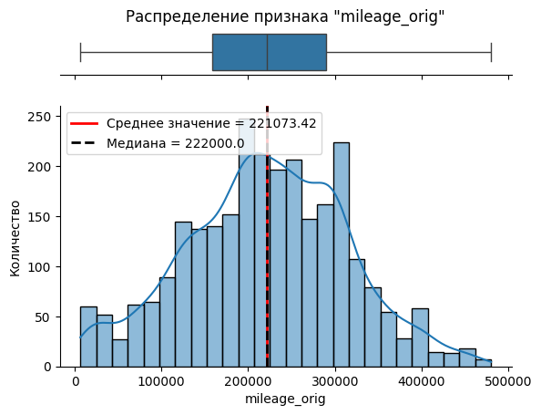

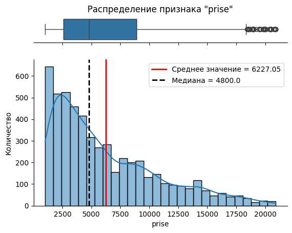

```
(5343, 22)
```

```
(718, 22)
```

## Таргет

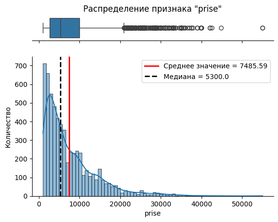

```
prise
2000.00    0.02
2500.00    0.02
3500.00    0.02
4500.00    0.02
1500.00    0.02
           ...
17777.00   0.00
4836.00    0.00
6555.00    0.00
3468.00    0.00
3420.00    0.00
Name: proportion, Length: 602, dtype: float64
```

Данные распределены не нормально и имеют выбросы и длинный правый хвост. В данных есть значимые расхождения между средним и медианой.

## Категориальные признаки

```
['brend',
 'tip_dvigatelja',
 'body',
 'door',
 'fuel',
 'transmission',
 'contact',
 'fone',
 'model']
```

```
------------------------------------------------------------------------------------------------------------------------------------------------------
Зависимость признака BREND от таргета: 0.22
                  mean   median  count
brend
Audi           6018.95  3300.00    301
BMW            8138.97  5500.00    432
Ford           7421.98  7850.00    328
Honda          7524.48  6150.00    194
Lexus         14629.65 14000.00    497
Mercedes-Benz  6387.33  4450.00    580
Nissan         5287.28  3000.00    217
Opel           3031.86  2800.00    248
Toyota         9149.98  7500.00    911
Volkswagen     4962.46  4000.00    843
другие         7122.16  4500.00   1510
```

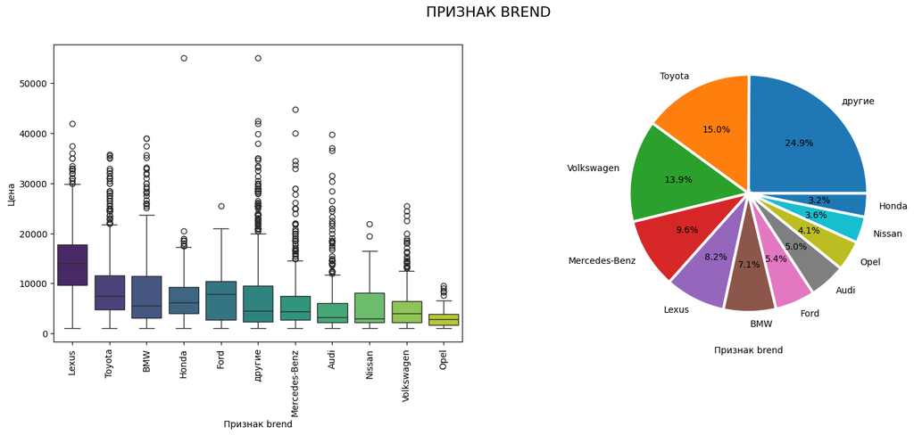

```
------------------------------------------------------------------------------------------------------------------------------------------------------
Зависимость признака TIP_DVIGATELJA от таргета: 0.24
                   mean   median  count
tip_dvigatelja
NoInfo          6792.95  4900.00    217
Бензин          7193.45  3800.00   1424
Бензин-Газ      5335.13  3800.00   1225
Гибрид         13202.67 11725.00    944
Дизель          5981.07  4500.00   2132
Электро        15984.47 14900.00    119
```

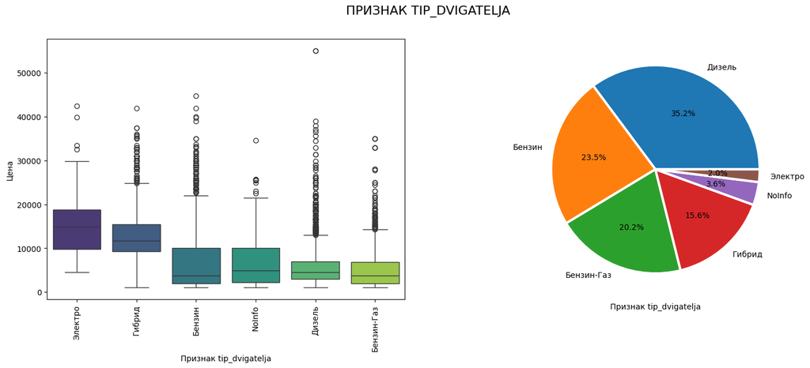

```
------------------------------------------------------------------------------------------------------------------------------------------------------
Зависимость признака BODY от таргета: 0.18
                 mean   median  count
body
NoInfo        7490.77  5300.00    675
внедорожник  12858.49 10700.00    703
другие        6221.15  4600.00     62
кроссовер    13946.49 12349.00    445
купе          5558.57  2950.00     56
лимузин       8078.68  5162.50     34
микроавтобус  6828.76  6300.00     66
минивен       5121.63  4499.50    608
седан         7027.28  4999.00   1827
универсал     4351.46  3500.00    925
хетчбек       5557.50  4125.00    660
```

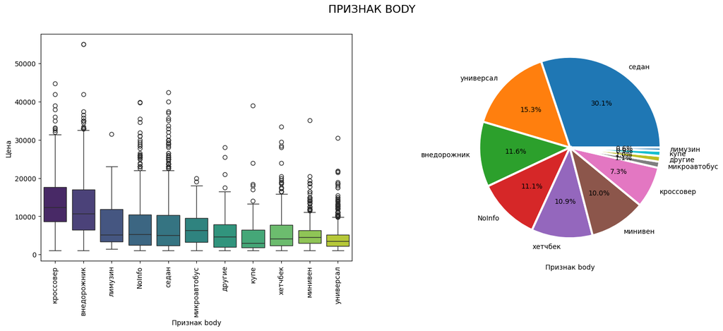

```
------------------------------------------------------------------------------------------------------------------------------------------------------
Зависимость признака DOOR от таргета: 0.01
          mean  median  count
door
2/3    4469.02 3200.00    138
4/5    7617.98 5500.00   5140
6/7    9791.90 6000.00     31
NoInfo 7039.25 5000.00    752
```

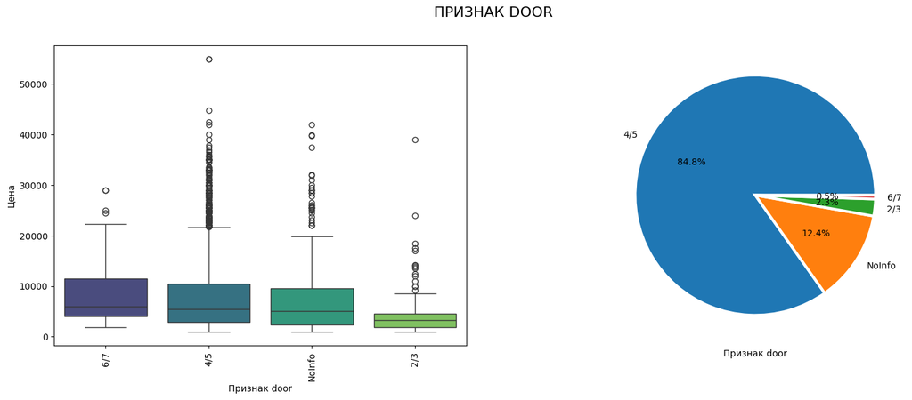

```
------------------------------------------------------------------------------------------------------------------------------------------------------
Зависимость признака FUEL от таргета: 0.1
            mean   median  count
fuel
NoInfo   7149.19  4940.00    519
бензин   8881.75  7600.00   2465
газ      5402.82  4000.00    799
дизель   6009.79  4590.00   2083
электро 15030.75 14500.00    195
```

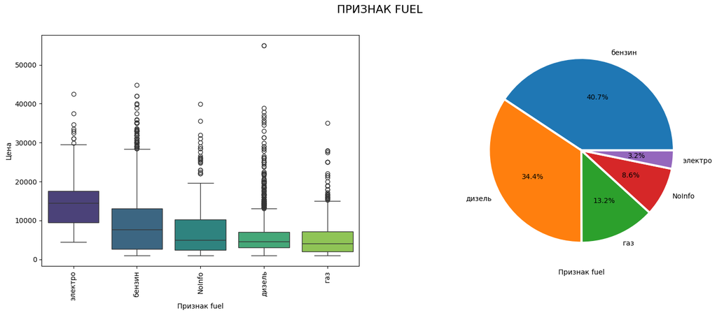

```
------------------------------------------------------------------------------------------------------------------------------------------------------
Зависимость признака TRANSMISSION от таргета: 0.33
                    mean  median  count
transmission
4-ёхступ.мех.    2282.79 1700.00     43
5-тиступ.мех.    3073.61 2500.00   1985
6-тиступ.мех.    5643.14 5000.00    747
NoInfo           6671.86 4150.00    378
автомат         11196.63 9700.00   2855
полуавтомат      6405.00 3800.00     10
роботизированая  9373.98 7900.00     43
```

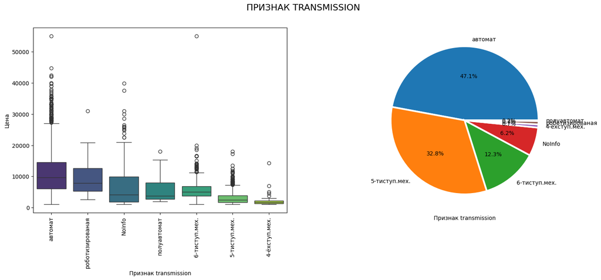

```
------------------------------------------------------------------------------------------------------------------------------------------------------
Зависимость признака CONTACT от таргета: 0.06
              mean   median  count
contact
USAuto    12575.73 11700.00    217
usauto    10992.30 10000.00    189
Александр  6184.03  4500.00    336
Андрей     6826.85  4450.00    168
Владимир   6368.30  4500.00    115
Дмитрий    6281.94  4450.00    176
Евгений    6398.40  4600.00    120
Игорь     11370.88 10000.00    170
Олег       7208.19  5800.00    164
Сергей     7334.67  5500.00    294
другие     7164.78  5000.00   4112
```

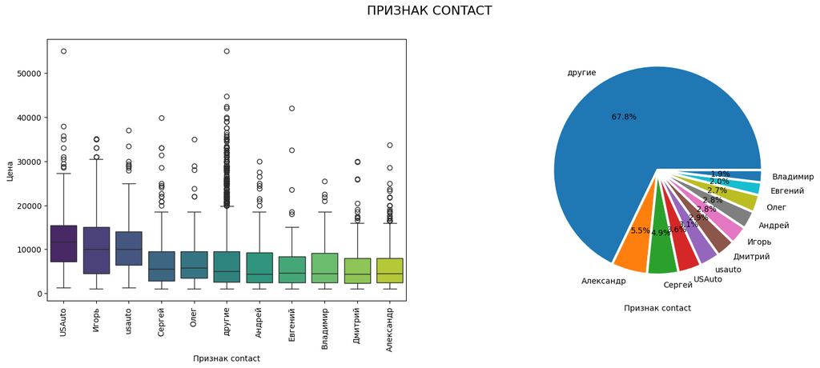

```
------------------------------------------------------------------------------------------------------------------------------------------------------
Зависимость признака FONE от таргета: 0.08
             mean   median  count
fone
77507809  1259.62  1200.00     26
77511713  8951.20  9400.00     20
77727210  9450.00  7500.00     16
77739797 12499.00 11500.00    497
77751105 15907.33 15900.00     15
77751188  6103.92  4590.00     37
77766577  6652.69  6099.50     54
77766745  7577.14  6250.00     21
77873962 10562.50 10500.00     24
77902820  7513.86  7700.00     22
другие    7017.00  4900.00   5329
```

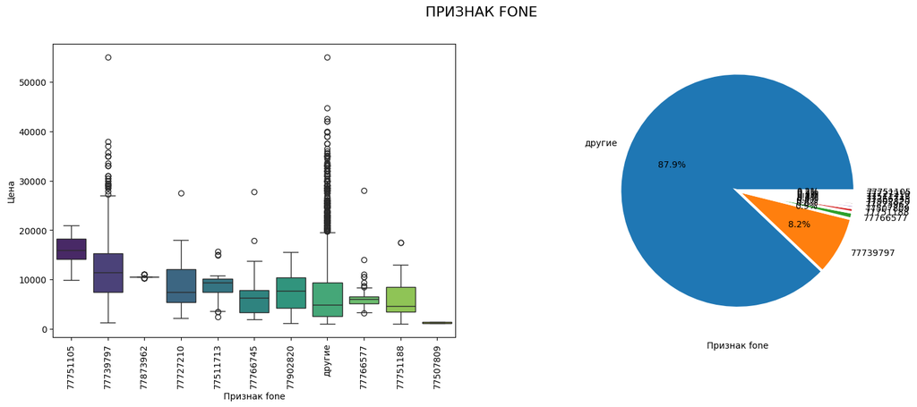

```
------------------------------------------------------------------------------------------------------------------------------------------------------
Зависимость признака MODEL от таргета: 0.21
            mean   median  count
model
A6       5906.50  3500.00    122
Avensis  4894.41  4545.00    174
Camry    9454.02  9950.00    169
Fusion  11697.17 11700.00    111
Golf     3942.34  3500.00    149
Passat   3752.06  2600.00    335
Prius    7305.96  6600.00    119
RX 400h 10073.62  9925.00    110
RX 450h 17924.17 17100.00    155
X5      11072.28  8825.00    110
другие   7340.54  5000.00   4507
```

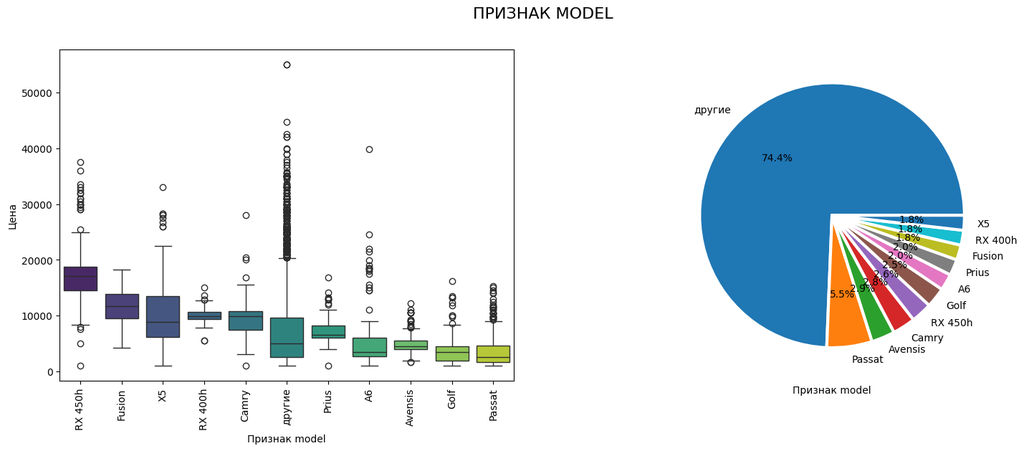

```
brend
Toyota           911
Volkswagen       843
Mercedes-Benz    580
Lexus            497
BMW              432
Ford             328
Audi             301
Opel             248
Nissan           217
Honda            194
Mazda            182
Mitsubishi       171
Hyundai          147
Chevrolet        101
Renault          101
Volvo             73
Kia               69
Skoda             59
Infiniti          52
ВАЗ               50
Chrysler          49
Tesla             48
Peugeot           44
SEAT              43
Lincoln           34
Citroen           32
Jeep              31
Dacia             21
Fiat              20
Land              18
ГАЗ               17
Suzuki            15
Dodge             15
Porsche           13
Subaru            13
Alfa              11
Acura             10
Rover             10
SsangYong          8
```

[output cut: 103 more lines]

```
----------------------------------------------------------------------------------------------------
model
Passat            335
Avensis           174
Camry             169
RX 450h           155
Golf              149
                 ...
31022               1
Stilo               1
310221              1
Serena              1
S-klasse S 280      1
Name: count, Length: 562, dtype: int64
----------------------------------------------------------------------------------------------------
```

```
------------------------------------------------------------------------------------------------------------------------------------------------------
Зависимость признака STATE от таргета: 0.19
                       mean   median  count
state
NoInfo              6533.78  4370.00    533
Битыйавто           1978.89  1200.00      9
Новый              12608.69 11000.00     62
Отличное            9933.80  8500.00   3252
Плохое              2000.00  2000.00      1
Удовлетворительное  2010.72  1575.00    142
Хорошее             4120.22  3100.00   2062
```

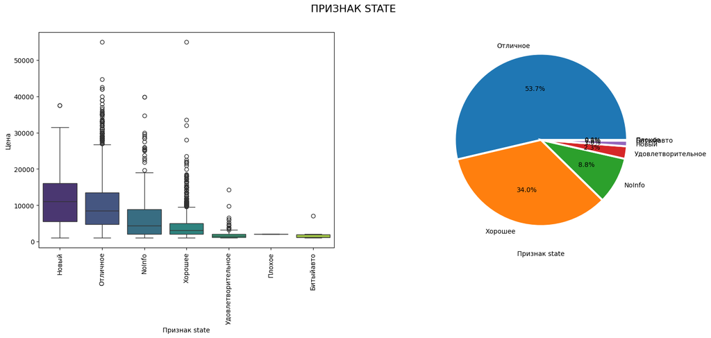

```
------------------------------------------------------------------------------------------------------------------------------------------------------
Зависимость признака CONDITIONER от таргета: 0.21
                   mean  median  count
conditioner
NoInfo          5190.33 3000.00   1006
безкондиционера 2112.19 1600.00    356
климатконтроль  9994.83 8500.00   3222
кондиционер     4870.29 3700.00   1477
```

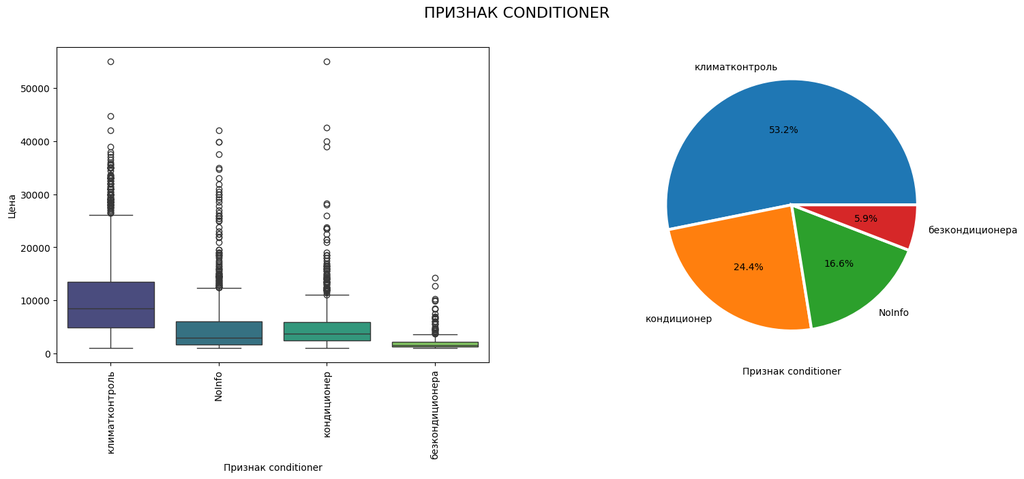

```
------------------------------------------------------------------------------------------------------------------------------------------------------
Зависимость признака AUDIO от таргета: 0.14
                                        mean   median  count
audio
NoInfo                               6507.33  4200.00   1575
автомагнитола                        4294.09  3000.00   1002
автомагнитолаCD/MP3(безUSB)          5276.77  4750.00    819
автомагнитолаCD/MP3(сUSBиBluetooth)  9504.47  8400.00   2340
автомагнитолаHi-End                 13096.41 12000.00    325
```

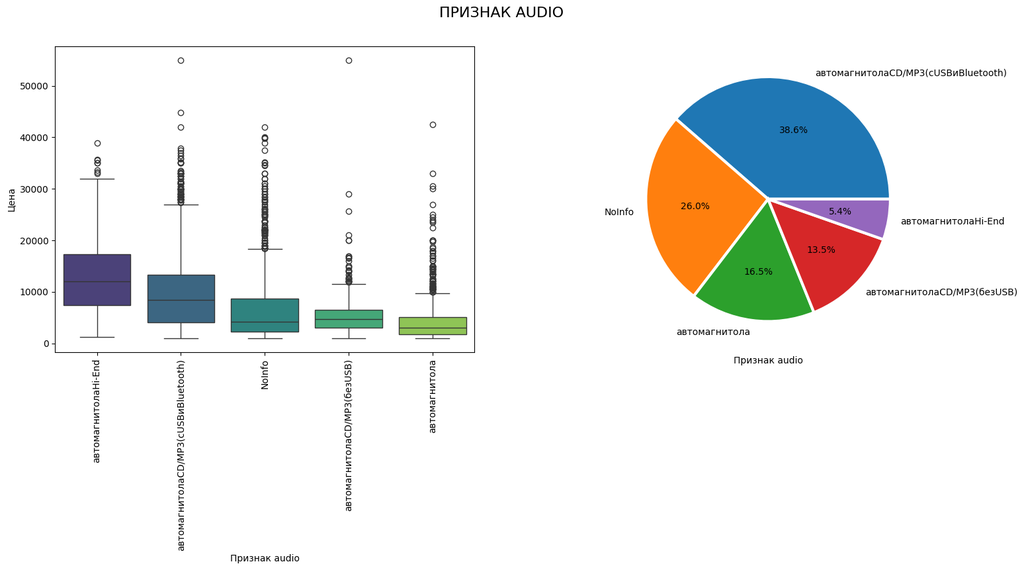

```
------------------------------------------------------------------------------------------------------------------------------------------------------
Зависимость признака Q_PRISE от таргета: 1.3
            mean   median  count
q_prise
A        3005.19  2800.00   3151
B        7752.21  7800.00   1411
C       12348.71 12300.00    756
D       16729.99 16600.00    399
E       23195.32 22752.50    248
F       33324.18 32000.00     96
```

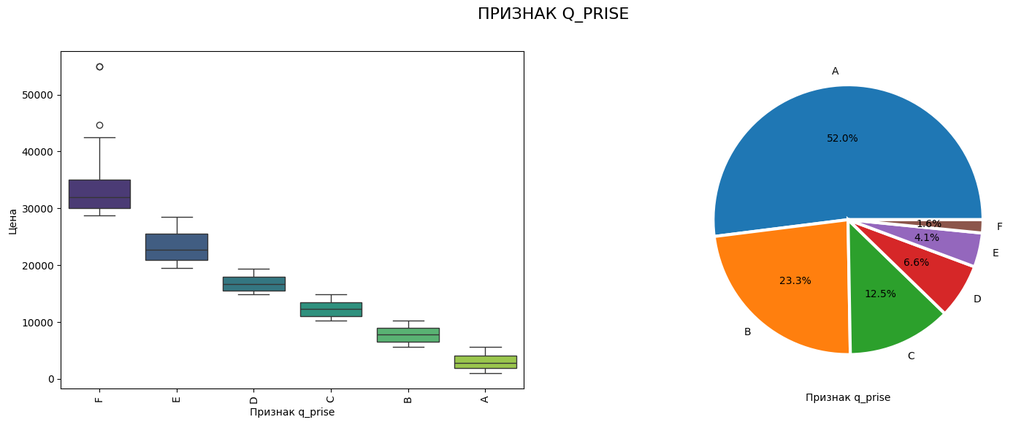

```
state
Отличное              3252
Хорошее               2062
NaN                    533
Удовлетворительное     142
Новый                   62
Битыйавто                9
Плохое                   1
Name: count, dtype: int64
----------------------------------------------------------------------------------------------------
conditioner
климатконтроль     3222
кондиционер        1477
NaN                1006
безкондиционера     356
Name: count, dtype: int64
----------------------------------------------------------------------------------------------------
audio
автомагнитолаCD/MP3(сUSBиBluetooth)    2340
NaN                                    1575
автомагнитола                          1002
автомагнитолаCD/MP3(безUSB)             819
автомагнитолаHi-End                     325
Name: count, dtype: int64
----------------------------------------------------------------------------------------------------
q_prise
A    3151
B    1411
C     756
D     399
E     248
F      96
Name: count, dtype: int64
----------------------------------------------------------------------------------------------------
```

- В данных больше всего объявлений о продаже автомобилей марок Toyota, Volkswagen и Mercedes. Но дороже автомобили марки Lexus.
- Больше всего дизельных и бензиновых автомобилей, но дороже автомобили с электрическим приводом.
- Больше всего представлены седаны, универсалы и внедорожники, но дороже автомобили в кузове кроссовера.
- 4х дверные автомобили с багажником преобладают на данном сайте, цены не влияют критически на количество дверей в автомобиле, за исключением 2х дверных автомобилей, они дешевле.
- автомобили с коробкой автомат занимают практически половину объявлений легковых автомобилей и наибольшую цену. на втором месте по количеству автомобилей идут машины с 5и ступенчатой механической коробкой передач.
- Данные о пользователе автомобиля не релевантны в дальнейшем эти данные можно удалить.
- 8.2% объявлений об автомобилях принадлежит пользователю с телефоном 777 39797
- Больше всего подано объявлений о продаже автомобилей модели Passat, Avensis, Camry и RX 450h. Наибольшая средняя цена у RX 450h, Fusion и X5.
- Больше половины автомобилей продается в отличном состоянии, на втором месте идут машины в хорошем состоянии
- Больше всего объявлений с автомобилями с системой климатконтроль, на втором месте автомобили с кондиционерами.
- 38% объявлений о продаже автомобилей с автомагнитолой с системой блютуз.
- В основном представлены автомобили бюджетного сегмента. Чем дороже автомобиль, тем меньше таких объявлений.
- Порядковые признаки добавлены верно видна взаимосвязь между категорией признака и ценой автомобиля.